# Naste Nutrient Analysis

### Treatment Aquaria

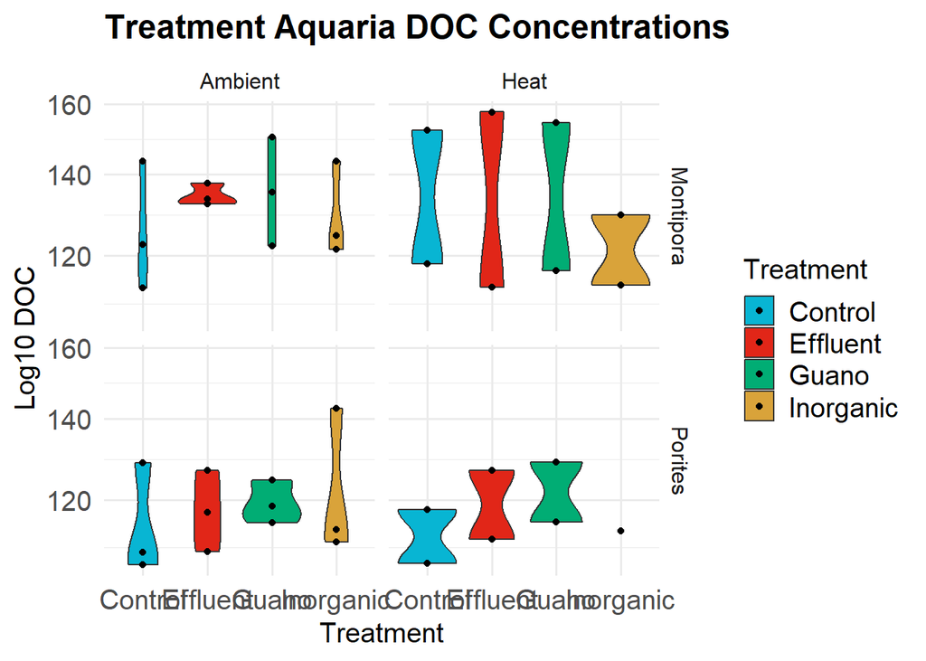

```r
# Violin Plot - DOC pooled at all timepoints
ggplot(data=subset(doc, Tank %in% c("Aquaria")), aes(x=Treatment, y=NPOC_uM, fill=Treatment))+
  geom_violin()+
  facet_grid(Species ~ Temperature) +
  geom_jitter(width=0)+
  ggtitle("Treatment Aquaria DOC Concentrations")+
  scale_fill_manual(values=naste_colors)+
  scale_y_continuous(trans = "log10", name = "Log10 DOC")
```

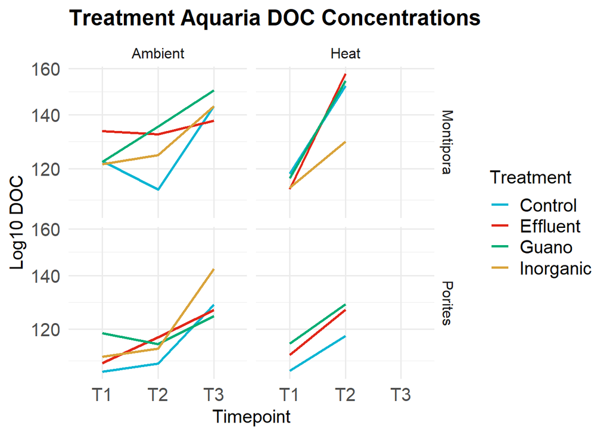

```r
# Line Plot - to show time series of DOC
  ### NOTE- Heated Porites Inorganic missing because possible outlier (removed in data wrangling chunk above)
ggplot(data=subset(doc, Tank %in% c("Aquaria")), aes(x=Timepoint, y=NPOC_uM, group=Treatment, color=Treatment))+
  geom_line(size = 1)+
  facet_grid(Species ~ Temperature)+
  ggtitle("Treatment Aquaria DOC Concentrations")+
  scale_color_manual(values= naste_colors)+
  scale_y_continuous(trans = "log10", name = "Log10 DOC")
```

### Analysis of DOC in aquaria - LME

```r
# Pooled Montipora and Porites data
DOC_aquaria <- doc %>%
  filter(Tank == "Aquaria") %>%
  lmer(log10(NPOC_uM) ~ Treatment * Timepoint + (1|Aquaria), data = .)
summary(DOC_aquaria)
```

```
## Linear mixed model fit by REML ['lmerMod']
## Formula: log10(NPOC_uM) ~ Treatment * Timepoint + (1 | Aquaria)
##    Data: .
##
## REML criterion at convergence: -83.3
##
## Scaled residuals:
##     Min      1Q  Median      3Q     Max
## -1.2207 -0.3871 -0.1671  0.2642  2.0210
##
## Random effects:
##  Groups   Name        Variance  Std.Dev.
##  Aquaria  (Intercept) 0.0005358 0.02315
##  Residual             0.0011889 0.03448
## Number of obs: 39, groups:  Aquaria, 16
##
## Fixed effects:
##                                 Estimate Std. Error t value
## (Intercept)                     2.053439   0.020765  98.889
## TreatmentEffluent               0.012224   0.029366   0.416
## TreatmentGuano                  0.018824   0.029366   0.641
## TreatmentInorganic              0.005951   0.029366   0.203
## TimepointT2                     0.032081   0.024381   1.316
## TimepointT3                     0.088982   0.031018   2.869
## TreatmentEffluent:TimepointT2   0.025181   0.034481   0.730
## TreatmentGuano:TimepointT2      0.018598   0.034481   0.539
## TreatmentInorganic:TimepointT2 -0.004124   0.036315  -0.114
## TreatmentEffluent:TimepointT3  -0.030774   0.043867  -0.702
## TreatmentGuano:TimepointT3     -0.020676   0.043867  -0.471
## TreatmentInorganic:TimepointT3  0.009081   0.043950   0.207
##
## Correlation of Fixed Effects:
##             (Intr) TrtmnE TrtmnG TrtmnI TmpnT2 TmpnT3 TE:TT2 TG:TT2 TI:TT2
## TrtmntEffln -0.707
## TreatmentGn -0.707  0.500
## TrtmntInrgn -0.707  0.500  0.500
## TimepointT2 -0.587  0.415  0.415  0.415
## TimepointT3 -0.461  0.326  0.326  0.326  0.393
## TrtmntE:TT2  0.415 -0.587 -0.294 -0.294 -0.707 -0.278
## TrtmntG:TT2  0.415 -0.294 -0.587 -0.294 -0.707 -0.278  0.500
## TrtmntI:TT2  0.394 -0.279 -0.279 -0.557 -0.671 -0.264  0.475  0.475
## TrtmntE:TT3  0.326 -0.461 -0.231 -0.231 -0.278 -0.707  0.393  0.197  0.187
## TrtmntG:TT3  0.326 -0.231 -0.461 -0.231 -0.278 -0.707  0.197  0.393  0.187
## TrtmntI:TT3  0.326 -0.230 -0.230 -0.461 -0.277 -0.706  0.196  0.196  0.392
##             TE:TT3 TG:TT3
## TrtmntEffln
## TreatmentGn
## TrtmntInrgn
## TimepointT2
## TimepointT3
## TrtmntE:TT2
## TrtmntG:TT2
## TrtmntI:TT2
## TrtmntE:TT3
## TrtmntG:TT3  0.500
## TrtmntI:TT3  0.499  0.499
```

```r
emm_doc_a<- emmeans(DOC_aquaria, ~ Treatment)
```

```
## NOTE: Results may be misleading due to involvement in interactions
```

```r
emm_doc_a
```

```
##  Treatment emmean     SE   df lower.CL upper.CL
##  Control     2.09 0.0167 11.8     2.06     2.13
##  Effluent    2.10 0.0167 11.8     2.07     2.14
##  Guano       2.11 0.0167 11.8     2.08     2.15
##  Inorganic   2.10 0.0175 12.3     2.06     2.14
##
## Results are averaged over the levels of: Timepoint
## Degrees-of-freedom method: kenward-roger
## Results are given on the log10 (not the response) scale.
## Confidence level used: 0.95
```

```r
pair_doc_a<- contrast(emm_doc_a, method='pairwise')
summary(pair_doc_a)
```

```
##  contrast             estimate     SE   df t.ratio p.value
##  Control - Effluent   -0.01036 0.0236 11.8  -0.439  0.9705
##  Control - Guano      -0.01813 0.0236 11.8  -0.768  0.8671
##  Control - Inorganic  -0.00760 0.0242 12.0  -0.314  0.9887
##  Effluent - Guano     -0.00777 0.0236 11.8  -0.329  0.9870
##  Effluent - Inorganic  0.00276 0.0242 12.0   0.114  0.9994
##  Guano - Inorganic     0.01053 0.0242 12.0   0.435  0.9712
##
## Results are averaged over the levels of: Timepoint
## Degrees-of-freedom method: kenward-roger
## Results are given on the log10 (not the response) scale.
## P value adjustment: tukey method for comparing a family of 4 estimates
```

```r
# no differences

# Montipora
DOC_aquaria_m <- mc_doc %>%
  filter(Tank == "Aquaria") %>%
  lmer(log10(NPOC_uM) ~ Treatment * Timepoint + (1|Aquaria), data = .)
```

```
## boundary (singular) fit: see help('isSingular')
```

```r
summary(DOC_aquaria_m)
```

```
## Linear mixed model fit by REML ['lmerMod']
## Formula: log10(NPOC_uM) ~ Treatment * Timepoint + (1 | Aquaria)
##    Data: .
##
## REML criterion at convergence: -21.2
##
## Scaled residuals:
##     Min      1Q  Median      3Q     Max
## -1.4316 -0.2532  0.0000  0.2532  1.4316
##
## Random effects:
##  Groups   Name        Variance Std.Dev.
##  Aquaria  (Intercept) 0.000000 0.00000
##  Residual             0.002069 0.04549
## Number of obs: 20, groups:  Aquaria, 8
##
## Fixed effects:
##                                 Estimate Std. Error t value
## (Intercept)                     2.080713   0.032163  64.693
## TreatmentEffluent               0.009090   0.045485   0.200
## TreatmentGuano                 -0.003507   0.045485  -0.077
## TreatmentInorganic             -0.010797   0.045485  -0.237
## TimepointT2                     0.036983   0.045485   0.813
## TimepointT3                     0.076502   0.055708   1.373
## TreatmentEffluent:TimepointT2   0.033085   0.064326   0.514
## TreatmentGuano:TimepointT2      0.046245   0.064326   0.719
## TreatmentInorganic:TimepointT2 -0.002373   0.064326  -0.037
## TreatmentEffluent:TimepointT3  -0.027339   0.078782  -0.347
## TreatmentGuano:TimepointT3      0.023453   0.078782   0.298
## TreatmentInorganic:TimepointT3  0.010797   0.078782   0.137
##
## Correlation of Fixed Effects:
##             (Intr) TrtmnE TrtmnG TrtmnI TmpnT2 TmpnT3 TE:TT2 TG:TT2 TI:TT2
## TrtmntEffln -0.707
## TreatmentGn -0.707  0.500
## TrtmntInrgn -0.707  0.500  0.500
## TimepointT2 -0.707  0.500  0.500  0.500
## TimepointT3 -0.577  0.408  0.408  0.408  0.408
## TrtmntE:TT2  0.500 -0.707 -0.354 -0.354 -0.707 -0.289
## TrtmntG:TT2  0.500 -0.354 -0.707 -0.354 -0.707 -0.289  0.500
## TrtmntI:TT2  0.500 -0.354 -0.354 -0.707 -0.707 -0.289  0.500  0.500
## TrtmntE:TT3  0.408 -0.577 -0.289 -0.289 -0.289 -0.707  0.408  0.204  0.204
## TrtmntG:TT3  0.408 -0.289 -0.577 -0.289 -0.289 -0.707  0.204  0.408  0.204
## TrtmntI:TT3  0.408 -0.289 -0.289 -0.577 -0.289 -0.707  0.204  0.204  0.408
##             TE:TT3 TG:TT3
## TrtmntEffln
## TreatmentGn
## TrtmntInrgn
## TimepointT2
## TimepointT3
## TrtmntE:TT2
## TrtmntG:TT2
## TrtmntI:TT2
## TrtmntE:TT3
## TrtmntG:TT3  0.500
## TrtmntI:TT3  0.500  0.500
## optimizer (nloptwrap) convergence code: 0 (OK)
## boundary (singular) fit: see help('isSingular')
```

```r
emm_doc_a_m<- emmeans(DOC_aquaria_m, ~ Treatment)
```

```
## NOTE: Results may be misleading due to involvement in interactions
```

```r
emm_doc_a_m
```

```
##  Treatment emmean    SE   df lower.CL upper.CL
##  Control     2.12 0.024 2.46     2.03     2.21
##  Effluent    2.13 0.024 2.46     2.04     2.22
##  Guano       2.14 0.024 2.46     2.05     2.22
##  Inorganic   2.11 0.024 2.46     2.02     2.20
##
## Results are averaged over the levels of: Timepoint
## Degrees-of-freedom method: kenward-roger
## Results are given on the log10 (not the response) scale.
## Confidence level used: 0.95
```

```r
pair_doc_a_m<- contrast(emm_doc_a_m, method='pairwise')
summary(pair_doc_a_m)
```

```
##  contrast             estimate     SE   df t.ratio p.value
##  Control - Effluent   -0.01100 0.0339 2.46  -0.325  0.9856
##  Control - Guano      -0.01973 0.0339 2.46  -0.582  0.9304
##  Control - Inorganic   0.00799 0.0339 2.46   0.236  0.9943
##  Effluent - Guano     -0.00872 0.0339 2.46  -0.257  0.9926
##  Effluent - Inorganic  0.01899 0.0339 2.46   0.560  0.9368
##  Guano - Inorganic     0.02771 0.0339 2.46   0.817  0.8445
##
## Results are averaged over the levels of: Timepoint
## Degrees-of-freedom method: kenward-roger
## Results are given on the log10 (not the response) scale.
## P value adjustment: tukey method for comparing a family of 4 estimates
```

```r
# no differences

# Porites
DOC_aquaria_p <- pc_doc %>%
  filter(Tank == "Aquaria") %>%
  lmer(log10(NPOC_uM) ~ Treatment * Timepoint + (1|Aquaria), data = .)
summary(DOC_aquaria_p)
```

```
## Linear mixed model fit by REML ['lmerMod']
## Formula: log10(NPOC_uM) ~ Treatment * Timepoint + (1 | Aquaria)
##    Data: .
##
## REML criterion at convergence: -17.3
##
## Scaled residuals:
##      Min       1Q   Median       3Q      Max
## -1.83865 -0.08133  0.00000  0.08133  1.83865
##
## Random effects:
##  Groups   Name        Variance  Std.Dev.
##  Aquaria  (Intercept) 0.0002261 0.01504
##  Residual             0.0031558 0.05618
## Number of obs: 20, groups:  Aquaria, 8
##
## Fixed effects:
##                                Estimate Std. Error t value
## (Intercept)                     2.02617    0.04112  49.273
## TreatmentEffluent               0.01536    0.05815   0.264
## TreatmentGuano                  0.04115    0.05815   0.708
## TreatmentInorganic              0.02270    0.05815   0.390
## TimepointT2                     0.02718    0.05618   0.484
## TimepointT3                     0.08479    0.06952   1.220
## TreatmentEffluent:TimepointT2   0.01728    0.07945   0.217
## TreatmentGuano:TimepointT2     -0.00905    0.07945  -0.114
## TreatmentInorganic:TimepointT2  0.08927    0.07945   1.124
## TreatmentEffluent:TimepointT3  -0.02179    0.09831  -0.222
## TreatmentGuano:TimepointT3     -0.05568    0.09831  -0.566
## TreatmentInorganic:TimepointT3  0.02802    0.09831   0.285
##
## Correlation of Fixed Effects:
##             (Intr) TrtmnE TrtmnG TrtmnI TmpnT2 TmpnT3 TE:TT2 TG:TT2 TI:TT2
## TrtmntEffln -0.707
## TreatmentGn -0.707  0.500
## TrtmntInrgn -0.707  0.500  0.500
## TimepointT2 -0.683  0.483  0.483  0.483
## TimepointT3 -0.552  0.390  0.390  0.390  0.404
## TrtmntE:TT2  0.483 -0.683 -0.342 -0.342 -0.707 -0.286
## TrtmntG:TT2  0.483 -0.342 -0.683 -0.342 -0.707 -0.286  0.500
## TrtmntI:TT2  0.483 -0.342 -0.342 -0.683 -0.707 -0.286  0.500  0.500
## TrtmntE:TT3  0.390 -0.552 -0.276 -0.276 -0.286 -0.707  0.404  0.202  0.202
## TrtmntG:TT3  0.390 -0.276 -0.552 -0.276 -0.286 -0.707  0.202  0.404  0.202
## TrtmntI:TT3  0.390 -0.276 -0.276 -0.552 -0.286 -0.707  0.202  0.202  0.404
##             TE:TT3 TG:TT3
## TrtmntEffln
## TreatmentGn
## TrtmntInrgn
## TimepointT2
## TimepointT3
## TrtmntE:TT2
## TrtmntG:TT2
## TrtmntI:TT2
## TrtmntE:TT3
## TrtmntG:TT3  0.500
## TrtmntI:TT3  0.500  0.500
```

```r
emm_doc_a_p<- emmeans(DOC_aquaria_p, ~ Treatment)
```

```
## NOTE: Results may be misleading due to involvement in interactions
```

```r
emm_doc_a_p
```

```
##  Treatment emmean     SE   df lower.CL upper.CL
##  Control     2.06 0.0313 2.78     1.96     2.17
##  Effluent    2.08 0.0313 2.78     1.97     2.18
##  Guano       2.08 0.0313 2.78     1.98     2.19
##  Inorganic   2.13 0.0313 2.78     2.02     2.23
##
## Results are averaged over the levels of: Timepoint
## Degrees-of-freedom method: kenward-roger
## Results are given on the log10 (not the response) scale.
## Confidence level used: 0.95
```

```r
pair_doc_a_p<- contrast(emm_doc_a_p, method='pairwise')
summary(pair_doc_a_p)
```

```
##  contrast             estimate     SE   df t.ratio p.value
##  Control - Effluent   -0.01385 0.0442 2.78  -0.313  0.9873
##  Control - Guano      -0.01958 0.0442 2.78  -0.443  0.9665
##  Control - Inorganic  -0.06180 0.0442 2.78  -1.397  0.5808
##  Effluent - Guano     -0.00573 0.0442 2.78  -0.129  0.9990
##  Effluent - Inorganic -0.04794 0.0442 2.78  -1.084  0.7238
##  Guano - Inorganic    -0.04222 0.0442 2.78  -0.954  0.7839
##
## Results are averaged over the levels of: Timepoint
## Degrees-of-freedom method: kenward-roger
## Results are given on the log10 (not the response) scale.
## P value adjustment: tukey method for comparing a family of 4 estimates
```

```r
# no differences

# No differences between pooled and separated data
```

# TN - from DOC machine

### Dosing

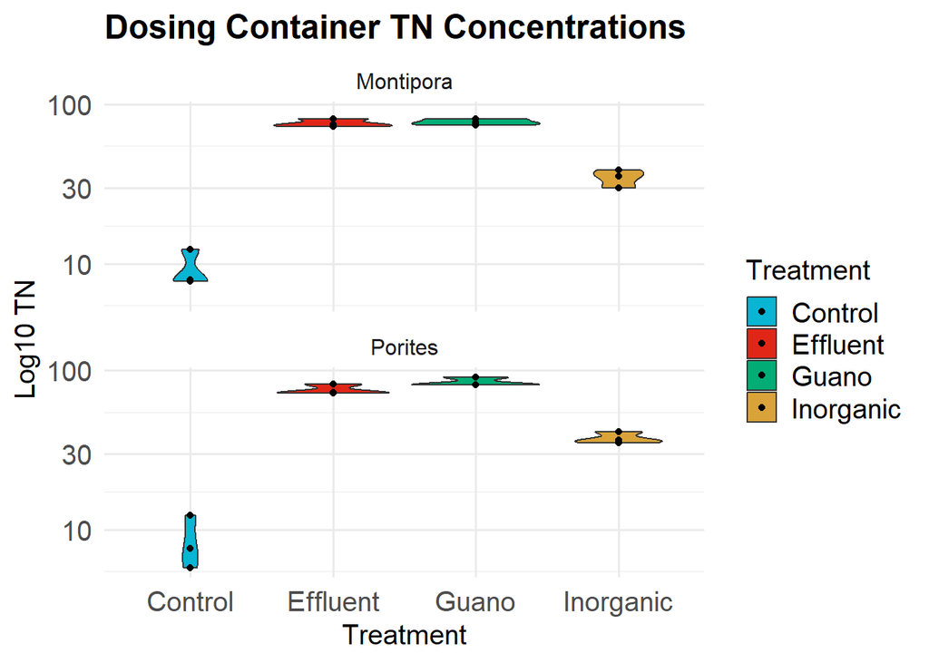

```r
# Violin Plot - TN pooled at all timepoints
ggplot(data=subset(doc, Tank %in% c("Dosing")), aes(x=Treatment, y=TN_uM, fill=Treatment))+
  geom_violin()+
  facet_wrap(~Species, ncol = 1) +
  geom_jitter(width=0)+
  ggtitle("Dosing Container TN Concentrations")+
  scale_fill_manual(values=naste_colors)+
  scale_y_continuous(trans = "log10", name = "Log10 TN")
```

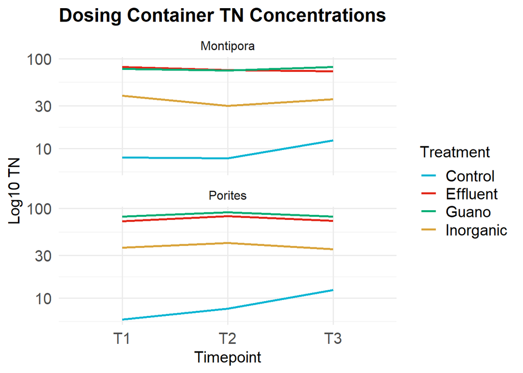

```r
# Line Plot - to show time series of TN
ggplot(data=subset(doc, Tank %in% c("Dosing")), aes(x=Timepoint, y=TN_uM, group=Treatment, color=Treatment))+
  geom_line(size = 1)+
  facet_wrap(~Species, ncol = 1)+
  ggtitle("Dosing Container TN Concentrations")+
  scale_color_manual(values= naste_colors)+
  scale_y_continuous(trans = "log10", name = "Log10 TN")
```

### Analysis of TN in Dosing - linear model

```r
# Pooled Montipora and Porites Data
TN2_dosing <- doc %>%
  filter(Tank == "Dosing") %>%
  lm(log10(TN_uM) ~ Treatment, data = .)
summary(TN2_dosing)
```

```
##
## Call:
## lm(formula = log10(TN_uM) ~ Treatment, data = .)
##
## Residuals:
##       Min        1Q    Median        3Q       Max
## -0.173417 -0.026192 -0.006392  0.031164  0.155571
##
## Coefficients:
##                    Estimate Std. Error t value Pr(>|t|)
## (Intercept)         0.93610    0.02935   31.89  < 2e-16 ***
## TreatmentEffluent   0.94350    0.04151   22.73 9.28e-16 ***
## TreatmentGuano      0.97081    0.04151   23.39 5.35e-16 ***
## TreatmentInorganic  0.62017    0.04151   14.94 2.59e-12 ***
## ---
## Signif. codes:  0 '***' 0.001 '**' 0.01 '*' 0.05 '.' 0.1 ' ' 1
##
## Residual standard error: 0.0719 on 20 degrees of freedom
## Multiple R-squared:  0.9726, Adjusted R-squared:  0.9685
## F-statistic: 236.5 on 3 and 20 DF,  p-value: 8.759e-16
```

```r
emm_tn2<- emmeans(TN2_dosing, ~ Treatment)
emm_tn2
```

```
##  Treatment emmean     SE df lower.CL upper.CL
##  Control    0.936 0.0294 20    0.875    0.997
##  Effluent   1.880 0.0294 20    1.818    1.941
##  Guano      1.907 0.0294 20    1.846    1.968
##  Inorganic  1.556 0.0294 20    1.495    1.617
##
## Results are given on the log10 (not the response) scale.
## Confidence level used: 0.95
```

```r
pair_tn2<- contrast(emm_tn2, method='pairwise')
summary(pair_tn2)
```

```
##  contrast             estimate     SE df t.ratio p.value
##  Control - Effluent    -0.9435 0.0415 20 -22.728  <.0001
##  Control - Guano       -0.9708 0.0415 20 -23.386  <.0001
##  Control - Inorganic   -0.6202 0.0415 20 -14.940  <.0001
##  Effluent - Guano      -0.0273 0.0415 20  -0.658  0.9115
##  Effluent - Inorganic   0.3233 0.0415 20   7.789  <.0001
##  Guano - Inorganic      0.3506 0.0415 20   8.447  <.0001
##
## Results are given on the log10 (not the response) scale.
## P value adjustment: tukey method for comparing a family of 4 estimates
```

```r
# Effluent and guano similar but all other comparisons different

# Montipora
TN2_dosing_m <- mc_doc %>%
  filter(Tank == "Dosing") %>%
  lm(log10(TN_uM) ~ Treatment, data = .)
summary(TN2_dosing_m)
```

```
##
## Call:
## lm(formula = log10(TN_uM) ~ Treatment, data = .)
##
## Residuals:
##       Min        1Q    Median        3Q       Max
## -0.070040 -0.031320 -0.004247  0.022077  0.131765
##
## Coefficients:
##                    Estimate Std. Error t value Pr(>|t|)
## (Intercept)         0.95990    0.03784   25.37 6.25e-09 ***
## TreatmentEffluent   0.92246    0.05352   17.24 1.31e-07 ***
## TreatmentGuano      0.92841    0.05352   17.35 1.24e-07 ***
## TreatmentInorganic  0.57762    0.05352   10.79 4.79e-06 ***
## ---
## Signif. codes:  0 '***' 0.001 '**' 0.01 '*' 0.05 '.' 0.1 ' ' 1
##
## Residual standard error: 0.06554 on 8 degrees of freedom
## Multiple R-squared:  0.9804, Adjusted R-squared:  0.973
## F-statistic: 133.2 on 3 and 8 DF,  p-value: 3.625e-07
```

```r
emm_tn2_m<- emmeans(TN2_dosing_m, ~ Treatment)
emm_tn2_m
```

```
##  Treatment emmean     SE df lower.CL upper.CL
##  Control     0.96 0.0378  8    0.873     1.05
##  Effluent    1.88 0.0378  8    1.795     1.97
##  Guano       1.89 0.0378  8    1.801     1.98
##  Inorganic   1.54 0.0378  8    1.450     1.62
##
## Results are given on the log10 (not the response) scale.
## Confidence level used: 0.95
```

```r
pair_tn2_m<- contrast(emm_tn2_m, method='pairwise')
summary(pair_tn2_m)
```

```
##  contrast             estimate     SE df t.ratio p.value
##  Control - Effluent   -0.92246 0.0535  8 -17.237  <.0001
##  Control - Guano      -0.92841 0.0535  8 -17.348  <.0001
##  Control - Inorganic  -0.57762 0.0535  8 -10.793  <.0001
##  Effluent - Guano     -0.00595 0.0535  8  -0.111  0.9995
##  Effluent - Inorganic  0.34484 0.0535  8   6.444  0.0009
##  Guano - Inorganic     0.35079 0.0535  8   6.555  0.0008
##
## Results are given on the log10 (not the response) scale.
## P value adjustment: tukey method for comparing a family of 4 estimates
```

```r
# Effluent and guano similar but all other comparisons different

# Porites
TN2_dosing_p <- pc_doc %>%
  filter(Tank == "Dosing") %>%
  lm(log10(TN_uM) ~ Treatment, data = .)
summary(TN2_dosing_p)
```

```
##
## Call:
## lm(formula = log10(TN_uM) ~ Treatment, data = .)
##
## Residuals:
##      Min       1Q   Median       3Q      Max
## -0.14961 -0.02162 -0.01502  0.03243  0.17938
##
## Coefficients:
##                    Estimate Std. Error t value Pr(>|t|)
## (Intercept)         0.91229    0.05058  18.037 9.16e-08 ***
## TreatmentEffluent   0.96453    0.07153  13.484 8.78e-07 ***
## TreatmentGuano      1.01321    0.07153  14.165 6.00e-07 ***
## TreatmentInorganic  0.66272    0.07153   9.265 1.50e-05 ***
## ---
## Signif. codes:  0 '***' 0.001 '**' 0.01 '*' 0.05 '.' 0.1 ' ' 1
##
## Residual standard error: 0.08761 on 8 degrees of freedom
## Multiple R-squared:  0.9696, Adjusted R-squared:  0.9582
## F-statistic:  85.1 on 3 and 8 DF,  p-value: 2.072e-06
```

```r
emm_tn2_p<- emmeans(TN2_dosing_p, ~ Treatment)
emm_tn2_p
```

```
##  Treatment emmean     SE df lower.CL upper.CL
##  Control    0.912 0.0506  8    0.796     1.03
##  Effluent   1.877 0.0506  8    1.760     1.99
##  Guano      1.925 0.0506  8    1.809     2.04
##  Inorganic  1.575 0.0506  8    1.458     1.69
##
## Results are given on the log10 (not the response) scale.
## Confidence level used: 0.95
```

```r
pair_tn2_p<- contrast(emm_tn2_p, method='pairwise')
summary(pair_tn2_p)
```

```
##  contrast             estimate     SE df t.ratio p.value
##  Control - Effluent    -0.9645 0.0715  8 -13.484  <.0001
##  Control - Guano       -1.0132 0.0715  8 -14.165  <.0001
##  Control - Inorganic   -0.6627 0.0715  8  -9.265  0.0001
##  Effluent - Guano      -0.0487 0.0715  8  -0.680  0.9017
##  Effluent - Inorganic   0.3018 0.0715  8   4.219  0.0124
##  Guano - Inorganic      0.3505 0.0715  8   4.900  0.0052
##
## Results are given on the log10 (not the response) scale.
## P value adjustment: tukey method for comparing a family of 4 estimates
```

```r
# Effluent and guano similar but all other comparisons different

# No differences between pooled and separated data
```

### Treatment Aquaria

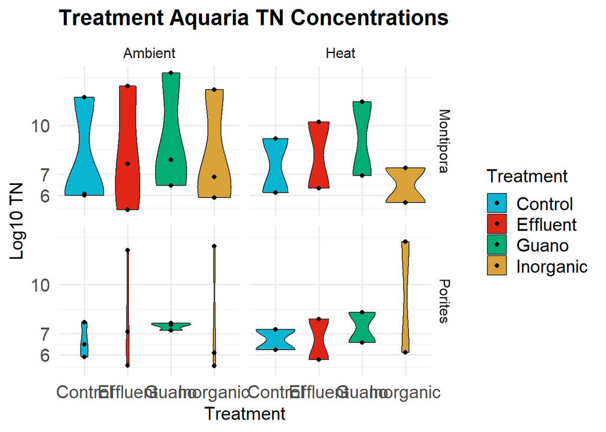

```r
# Violin Plot - TN pooled at all timepoints
ggplot(data=subset(doc, Tank %in% c("Aquaria")), aes(x=Treatment, y=TN_uM, fill=Treatment))+
  geom_violin()+
  facet_grid(Species ~ Temperature) +
  geom_jitter(width=0)+
  ggtitle("Treatment Aquaria TN Concentrations")+
  scale_fill_manual(values=naste_colors)+
  scale_y_continuous(trans = "log10", name = "Log10 TN")
```

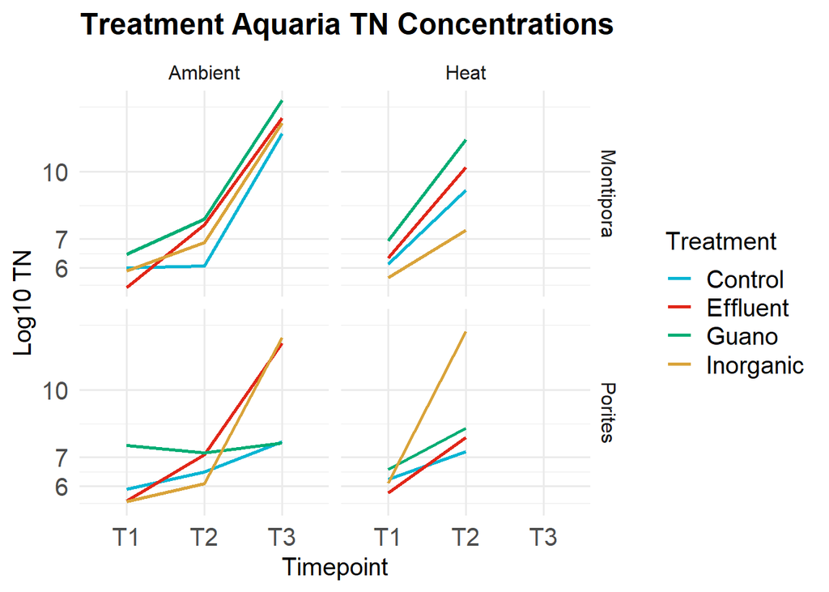

```r
# Line Plot - to show time series of TN
ggplot(data=subset(doc, Tank %in% c("Aquaria")), aes(x=Timepoint, y=TN_uM, group=Treatment, color=Treatment))+
  geom_line(size = 1)+
  facet_grid(Species ~ Temperature)+
  ggtitle("Treatment Aquaria TN Concentrations")+
  scale_color_manual(values= naste_colors)+
  scale_y_continuous(trans = "log10", name = "Log10 TN")
```

```r
# Pooled Montipora and Porites data
TN2_aquaria <- doc %>%
  filter(Tank == "Aquaria") %>%
  lmer(log10(TN_uM) ~ Treatment * Timepoint + (1|Aquaria), data = .)
summary(TN2_aquaria)
```

```
## Linear mixed model fit by REML ['lmerMod']
## Formula: log10(TN_uM) ~ Treatment * Timepoint + (1 | Aquaria)
##    Data: .
##
## REML criterion at convergence: -44.6
##
## Scaled residuals:
##      Min       1Q   Median       3Q      Max
## -1.64168 -0.36563 -0.07553  0.09210  2.59731
##
## Random effects:
##  Groups   Name        Variance  Std.Dev.
##  Aquaria  (Intercept) 0.0005217 0.02284
##  Residual             0.0067698 0.08228
## Number of obs: 40, groups:  Aquaria, 16
##
## Fixed effects:
##                                Estimate Std. Error t value
## (Intercept)                     0.78293    0.04270  18.338
## TreatmentEffluent              -0.02254    0.06038  -0.373
## TreatmentGuano                  0.05240    0.06038   0.868
## TreatmentInorganic             -0.01867    0.06038  -0.309
## TimepointT2                     0.06960    0.05818   1.196
## TimepointT3                     0.20641    0.07204   2.865
## TreatmentEffluent:TimepointT2   0.07793    0.08228   0.947
## TreatmentGuano:TimepointT2      0.02811    0.08228   0.342
## TreatmentInorganic:TimepointT2  0.07168    0.08228   0.871
## TreatmentEffluent:TimepointT3   0.15407    0.10189   1.512
## TreatmentGuano:TimepointT3     -0.01636    0.10189  -0.161
## TreatmentInorganic:TimepointT3  0.15371    0.10189   1.509
##
## Correlation of Fixed Effects:
##             (Intr) TrtmnE TrtmnG TrtmnI TmpnT2 TmpnT3 TE:TT2 TG:TT2 TI:TT2
## TrtmntEffln -0.707
## TreatmentGn -0.707  0.500
## TrtmntInrgn -0.707  0.500  0.500
## TimepointT2 -0.681  0.482  0.482  0.482
## TimepointT3 -0.550  0.389  0.389  0.389  0.404
## TrtmntE:TT2  0.482 -0.681 -0.341 -0.341 -0.707 -0.286
## TrtmntG:TT2  0.482 -0.341 -0.681 -0.341 -0.707 -0.286  0.500
## TrtmntI:TT2  0.482 -0.341 -0.341 -0.681 -0.707 -0.286  0.500  0.500
## TrtmntE:TT3  0.389 -0.550 -0.275 -0.275 -0.286 -0.707  0.404  0.202  0.202
## TrtmntG:TT3  0.389 -0.275 -0.550 -0.275 -0.286 -0.707  0.202  0.404  0.202
## TrtmntI:TT3  0.389 -0.275 -0.275 -0.550 -0.286 -0.707  0.202  0.202  0.404
##             TE:TT3 TG:TT3
## TrtmntEffln
## TreatmentGn
## TrtmntInrgn
## TimepointT2
## TimepointT3
## TrtmntE:TT2
## TrtmntG:TT2
## TrtmntI:TT2
## TrtmntE:TT3
## TrtmntG:TT3  0.500
## TrtmntI:TT3  0.500  0.500
```

```r
emm_tn2_a<- emmeans(TN2_aquaria, ~ Treatment)
```

```
## NOTE: Results may be misleading due to involvement in interactions
```

```r
emm_tn2_a
```

```
##  Treatment emmean     SE   df lower.CL upper.CL
##  Control    0.875 0.0305 11.4    0.808    0.942
##  Effluent   0.930 0.0305 11.4    0.863    0.997
##  Guano      0.931 0.0305 11.4    0.864    0.998
##  Inorganic  0.931 0.0305 11.4    0.865    0.998
##
## Results are averaged over the levels of: Timepoint
## Degrees-of-freedom method: kenward-roger
## Results are given on the log10 (not the response) scale.
## Confidence level used: 0.95
```

```r
pair_tn2_a<- contrast(emm_tn2_a, method='pairwise')
summary(pair_tn2_a)
```

```
##  contrast              estimate     SE   df t.ratio p.value
##  Control - Effluent   -0.054790 0.0431 11.4  -1.270  0.5982
##  Control - Guano      -0.056319 0.0431 11.4  -1.306  0.5776
##  Control - Inorganic  -0.056456 0.0431 11.4  -1.309  0.5758
##  Effluent - Guano     -0.001529 0.0431 11.4  -0.035  1.0000
##  Effluent - Inorganic -0.001667 0.0431 11.4  -0.039  1.0000
##  Guano - Inorganic    -0.000138 0.0431 11.4  -0.003  1.0000
##
## Results are averaged over the levels of: Timepoint
## Degrees-of-freedom method: kenward-roger
## Results are given on the log10 (not the response) scale.
## P value adjustment: tukey method for comparing a family of 4 estimates
```

```r
# no differences

# Montipora
TN2_aquaria_m <- mc_doc %>%
  filter(Tank == "Aquaria") %>%
  lmer(log10(TN_uM) ~ Treatment * Timepoint + (1|Aquaria), data = .)
summary(TN2_aquaria_m)
```

```
## Linear mixed model fit by REML ['lmerMod']
## Formula: log10(TN_uM) ~ Treatment * Timepoint + (1 | Aquaria)
##    Data: .
##
## REML criterion at convergence: -13.9
##
## Scaled residuals:
##     Min      1Q  Median      3Q     Max
## -1.0646 -0.2128  0.0000  0.2128  1.0646
##
## Random effects:
##  Groups   Name        Variance Std.Dev.
##  Aquaria  (Intercept) 0.001988 0.04458
##  Residual             0.003557 0.05964
## Number of obs: 20, groups:  Aquaria, 8
##
## Fixed effects:
##                                  Estimate Std. Error t value
## (Intercept)                     0.7831675  0.0526542  14.874
## TreatmentEffluent              -0.0162687  0.0744643  -0.218
## TreatmentGuano                  0.0426285  0.0744643   0.572
## TreatmentInorganic             -0.0194363  0.0744643  -0.261
## TimepointT2                     0.0874698  0.0596441   1.467
## TimepointT3                     0.3298840  0.0761936   4.330
## TreatmentEffluent:TimepointT2   0.0897549  0.0843496   1.064
## TreatmentGuano:TimepointT2      0.0689871  0.0843496   0.818
## TreatmentInorganic:TimepointT2 -0.0004869  0.0843496  -0.006
## TreatmentEffluent:TimepointT3   0.0539611  0.1077540   0.501
## TreatmentGuano:TimepointT3      0.0376047  0.1077540   0.349
## TreatmentInorganic:TimepointT3  0.0210488  0.1077540   0.195
##
## Correlation of Fixed Effects:
##             (Intr) TrtmnE TrtmnG TrtmnI TmpnT2 TmpnT3 TE:TT2 TG:TT2 TI:TT2
## TrtmntEffln -0.707
## TreatmentGn -0.707  0.500
## TrtmntInrgn -0.707  0.500  0.500
## TimepointT2 -0.566  0.400  0.400  0.400
## TimepointT3 -0.443  0.314  0.314  0.314  0.391
## TrtmntE:TT2  0.400 -0.566 -0.283 -0.283 -0.707 -0.277
## TrtmntG:TT2  0.400 -0.283 -0.566 -0.283 -0.707 -0.277  0.500
## TrtmntI:TT2  0.400 -0.283 -0.283 -0.566 -0.707 -0.277  0.500  0.500
## TrtmntE:TT3  0.314 -0.443 -0.222 -0.222 -0.277 -0.707  0.391  0.196  0.196
## TrtmntG:TT3  0.314 -0.222 -0.443 -0.222 -0.277 -0.707  0.196  0.391  0.196
## TrtmntI:TT3  0.314 -0.222 -0.222 -0.443 -0.277 -0.707  0.196  0.196  0.391
##             TE:TT3 TG:TT3
## TrtmntEffln
## TreatmentGn
## TrtmntInrgn
## TimepointT2
## TimepointT3
## TrtmntE:TT2
## TrtmntG:TT2
## TrtmntI:TT2
## TrtmntE:TT3
## TrtmntG:TT3  0.500
## TrtmntI:TT3  0.500  0.500
```

```r
emm_tn2_a_m<- emmeans(TN2_aquaria_m, ~ Treatment)
```

```
## NOTE: Results may be misleading due to involvement in interactions
```

```r
emm_tn2_a_m
```

```
##  Treatment emmean     SE   df lower.CL upper.CL
##  Control    0.922 0.0439 3.61    0.795     1.05
##  Effluent   0.954 0.0439 3.61    0.827     1.08
##  Guano      1.000 0.0439 3.61    0.873     1.13
##  Inorganic  0.910 0.0439 3.61    0.782     1.04
##
## Results are averaged over the levels of: Timepoint
## Degrees-of-freedom method: kenward-roger
## Results are given on the log10 (not the response) scale.
## Confidence level used: 0.95
```

```r
pair_tn2_a_m<- contrast(emm_tn2_a_m, method='pairwise')
summary(pair_tn2_a_m)
```

```
##  contrast             estimate     SE   df t.ratio p.value
##  Control - Effluent    -0.0316 0.0621 3.61  -0.509  0.9523
##  Control - Guano       -0.0782 0.0621 3.61  -1.258  0.6324
##  Control - Inorganic    0.0126 0.0621 3.61   0.203  0.9965
##  Effluent - Guano      -0.0465 0.0621 3.61  -0.749  0.8729
##  Effluent - Inorganic   0.0442 0.0621 3.61   0.712  0.8875
##  Guano - Inorganic      0.0907 0.0621 3.61   1.461  0.5369
##
## Results are averaged over the levels of: Timepoint
## Degrees-of-freedom method: kenward-roger
## Results are given on the log10 (not the response) scale.
## P value adjustment: tukey method for comparing a family of 4 estimates
```

```r
# no differences

# Porites
TN2_aquaria_p <- pc_doc %>%
  filter(Tank == "Aquaria") %>%
  lmer(log10(TN_uM) ~ Treatment * Timepoint + (1|Aquaria), data = .)
summary(TN2_aquaria_p)
```

```
## Linear mixed model fit by REML ['lmerMod']
## Formula: log10(TN_uM) ~ Treatment * Timepoint + (1 | Aquaria)
##    Data: .
##
## REML criterion at convergence: -10
##
## Scaled residuals:
##    Min     1Q Median     3Q    Max
## -1.732 -0.149  0.000  0.149  1.732
##
## Random effects:
##  Groups   Name        Variance Std.Dev.
##  Aquaria  (Intercept) 0.001692 0.04113
##  Residual             0.006824 0.08261
## Number of obs: 20, groups:  Aquaria, 8
##
## Fixed effects:
##                                Estimate Std. Error t value
## (Intercept)                     0.78269    0.06525  11.995
## TreatmentEffluent              -0.02881    0.09228  -0.312
## TreatmentGuano                  0.06217    0.09228   0.674
## TreatmentInorganic             -0.01791    0.09228  -0.194
## TimepointT2                     0.05173    0.08261   0.626
## TimepointT3                     0.10443    0.10393   1.005
## TreatmentEffluent:TimepointT2   0.06610    0.11683   0.566
## TreatmentGuano:TimepointT2     -0.01276    0.11683  -0.109
## TreatmentInorganic:TimepointT2  0.14385    0.11683   1.231
## TreatmentEffluent:TimepointT3   0.25534    0.14698   1.737
## TreatmentGuano:TimepointT3     -0.07050    0.14698  -0.480
## TreatmentInorganic:TimepointT3  0.28566    0.14698   1.943
##
## Correlation of Fixed Effects:
##             (Intr) TrtmnE TrtmnG TrtmnI TmpnT2 TmpnT3 TE:TT2 TG:TT2 TI:TT2
## TrtmntEffln -0.707
## TreatmentGn -0.707  0.500
## TrtmntInrgn -0.707  0.500  0.500
## TimepointT2 -0.633  0.448  0.448  0.448
## TimepointT3 -0.503  0.356  0.356  0.356  0.397
## TrtmntE:TT2  0.448 -0.633 -0.316 -0.316 -0.707 -0.281
## TrtmntG:TT2  0.448 -0.316 -0.633 -0.316 -0.707 -0.281  0.500
## TrtmntI:TT2  0.448 -0.316 -0.316 -0.633 -0.707 -0.281  0.500  0.500
## TrtmntE:TT3  0.356 -0.503 -0.252 -0.252 -0.281 -0.707  0.397  0.199  0.199
## TrtmntG:TT3  0.356 -0.252 -0.503 -0.252 -0.281 -0.707  0.199  0.397  0.199
## TrtmntI:TT3  0.356 -0.252 -0.252 -0.503 -0.281 -0.707  0.199  0.199  0.397
##             TE:TT3 TG:TT3
## TrtmntEffln
## TreatmentGn
## TrtmntInrgn
## TimepointT2
## TimepointT3
## TrtmntE:TT2
## TrtmntG:TT2
## TrtmntI:TT2
## TrtmntE:TT3
## TrtmntG:TT3  0.500
## TrtmntI:TT3  0.500  0.500
```

```r
emm_tn2_a_p<- emmeans(TN2_aquaria_p, ~ Treatment)
```

```
## NOTE: Results may be misleading due to involvement in interactions
```

```r
emm_tn2_a_p
```

```
##  Treatment emmean     SE   df lower.CL upper.CL
##  Control    0.835 0.0518 3.25    0.677    0.993
##  Effluent   0.913 0.0518 3.25    0.755    1.071
##  Guano      0.869 0.0518 3.25    0.711    1.027
##  Inorganic  0.960 0.0518 3.25    0.802    1.118
##
## Results are averaged over the levels of: Timepoint
## Degrees-of-freedom method: kenward-roger
## Results are given on the log10 (not the response) scale.
## Confidence level used: 0.95
```

```r
pair_tn2_a_p<- contrast(emm_tn2_a_p, method='pairwise')
summary(pair_tn2_a_p)
```

```
##  contrast             estimate     SE   df t.ratio p.value
##  Control - Effluent    -0.0783 0.0732 3.25  -1.070  0.7270
##  Control - Guano       -0.0344 0.0732 3.25  -0.470  0.9611
##  Control - Inorganic   -0.1253 0.0732 3.25  -1.711  0.4412
##  Effluent - Guano       0.0439 0.0732 3.25   0.600  0.9261
##  Effluent - Inorganic  -0.0469 0.0732 3.25  -0.641  0.9127
##  Guano - Inorganic     -0.0908 0.0732 3.25  -1.241  0.6445
##
## Results are averaged over the levels of: Timepoint
## Degrees-of-freedom method: kenward-roger
## Results are given on the log10 (not the response) scale.
## P value adjustment: tukey method for comparing a family of 4 estimates
```

```r
# no differences

# No differences between pooled and separated data
```

## Looking at the drawdown of TIN in the aquaria. The aquaria were filled at a rate of 1 L/hr and dosed at a rate of 0.109 L/hr nutrients and 0.891 L/hr seawater. I found the expected TIN for each of the tanks with the equation exptected_TIN = (0.109 * measured dosing container concentration) + (0.891 * 2.82). The measured HIMB seawater input was 2.82 umol/L TIN, so this was used in our equation as the added TIN from the seawater input.

```r
# upload csv with calculations

drawdown <- read.csv("C:\\Users\\jglaz\\Desktop\\Datasets\\nuts_drawdown.csv")

drawdown <- drawdown %>% drop_na()
```

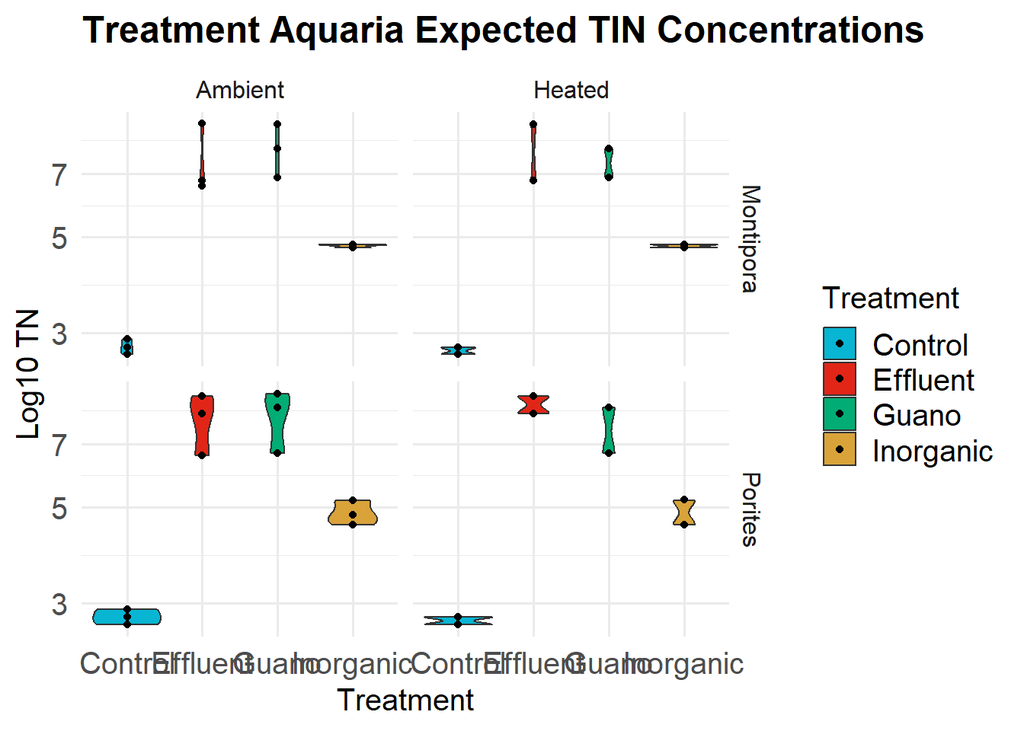

```r
# Violin Plot - expected TIN pooled at all timepoints
ggplot(data=drawdown, aes(x=Treatment, y=Expected_TIN, fill=Treatment))+
  geom_violin()+
  facet_grid(Species ~ Temperature) +
  geom_jitter(width=0)+
  ggtitle("Treatment Aquaria Expected TIN Concentrations")+
  scale_fill_manual(values=naste_colors)+
  scale_y_continuous(trans = "log10", name = "Log10 TN")
```

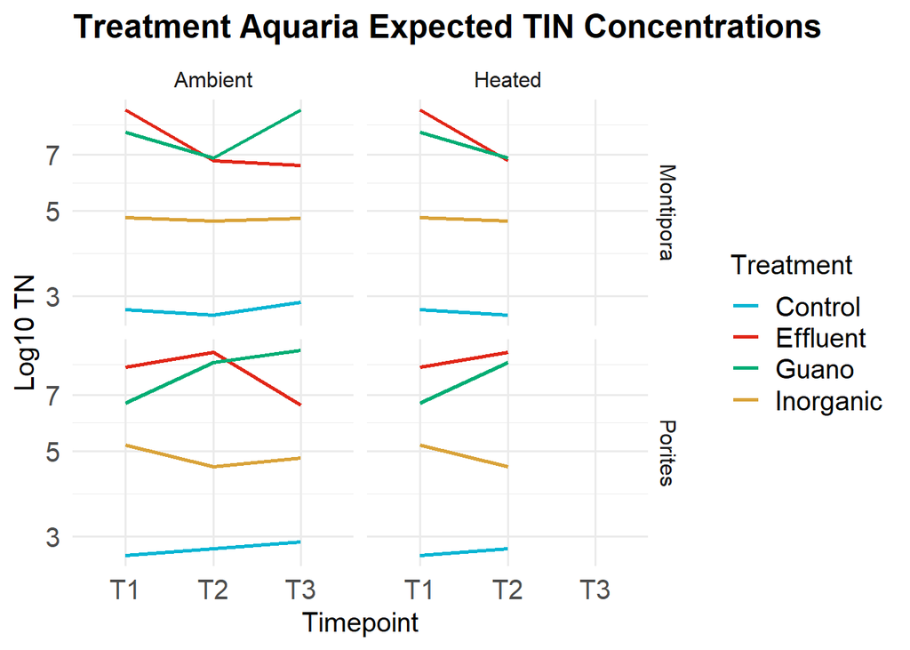

```r
# Line Plot - to show time series of expected TIN
ggplot(data=drawdown, aes(x=Timepoint, y=Expected_TIN, group=Treatment, color=Treatment))+
  geom_line(size = 1)+
  facet_grid(Species ~ Temperature)+
  ggtitle("Treatment Aquaria Expected TIN Concentrations")+
  scale_color_manual(values= naste_colors)+
  scale_y_continuous(trans = "log10", name = "Log10 TN")
```

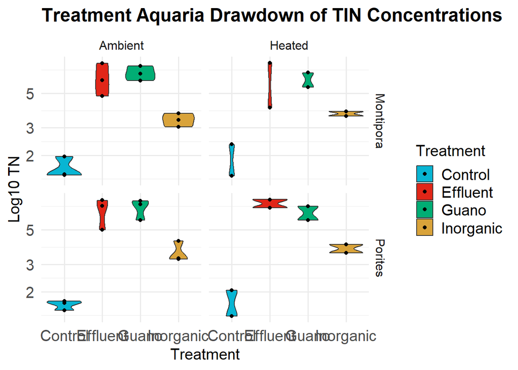

```r
# Violin Plot - drawdown of TIN pooled at all timepoints
ggplot(data=drawdown, aes(x=Treatment, y=Drawdown, fill=Treatment))+
  geom_violin()+
  facet_grid(Species ~ Temperature) +
  geom_jitter(width=0)+
  ggtitle("Treatment Aquaria Drawdown of TIN Concentrations")+
  scale_fill_manual(values=naste_colors)+
  scale_y_continuous(trans = "log10", name = "Log10 TN")
```

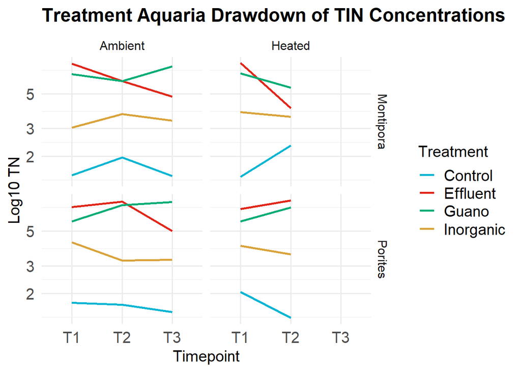

```r
# Line Plot - to show time series of expected TIN
ggplot(data=drawdown, aes(x=Timepoint, y=Drawdown, group=Treatment, color=Treatment))+
  geom_line(size = 1)+
  facet_grid(Species ~ Temperature)+
  ggtitle("Treatment Aquaria Drawdown of TIN Concentrations")+
  scale_color_manual(values= naste_colors)+
  scale_y_continuous(trans = "log10", name = "Log10 TN")
```

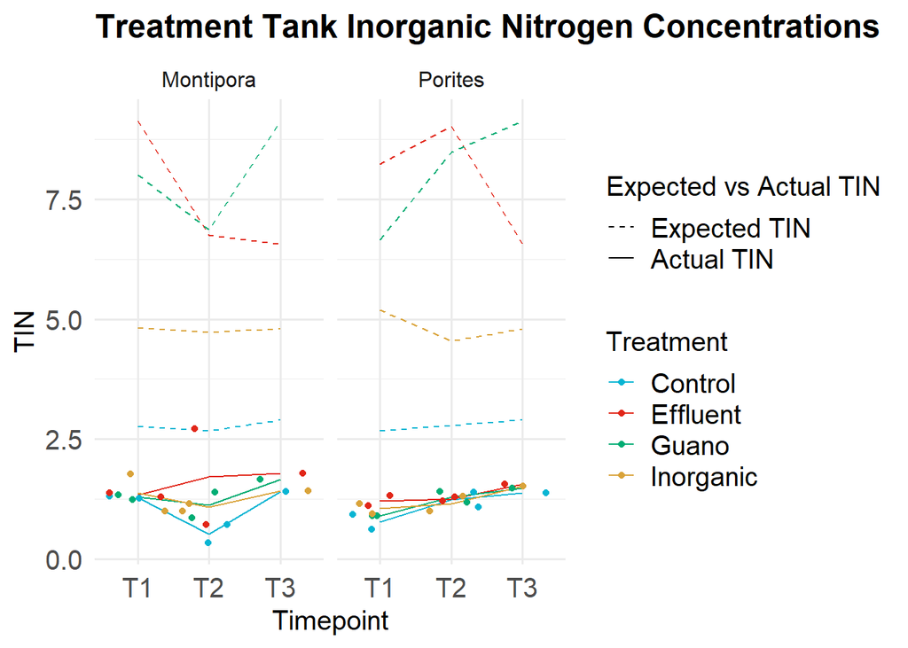

```r
ggplot()+
  geom_line(data=drawdown,
            aes(x=Timepoint, y=Expected_TIN, group=Treatment, color=Treatment, linetype="dashed"))+
geom_line(data = drawdown, aes(x = Timepoint, y = TIN, group = Treatment, color = Treatment, linetype="solid"),
          stat = "summary", fun = mean)+
  facet_wrap(~Species)+
  geom_jitter(data=drawdown,aes(x=Timepoint, y=TIN, color=Treatment))+
  ggtitle("Treatment Tank Inorganic Nitrogen Concentrations")+
  labs(y="TIN")+
  scale_color_manual(values= naste_colors)+
  scale_linetype_manual(
    values = c("dashed", "solid"),
    labels = c("Expected TIN", "Actual TIN")
  ) +
  labs(linetype = "Expected vs Actual TIN")
```